# Regresión, modelos y métodos

Prueba de evaluación continua 2

Jorge Vallejo Ortega

17 de January, 2021

# Ejercicio 1. Base de datos `diabetes.csv`

Como preparación al ejercicio, cargaremos los datos a memoria y examinaremos las características y estructura de los mismos.

```r
# Reading and loading data from file diabetes.txt
diabetes <- read.table("./data/diabetes.txt",
           header = TRUE
           )

kable(
  head(diabetes),
  caption = "Ejemplo de las primeras seis observaciones en la base de datos `diabetes`.",
  align = 'c'
)
```

Ejemplo de las primeras seis observaciones en la base de datos `diabetes`.

| glyhb | chol | stab.glu | hdl | age | bp.1s | bp.1d | cintura | cadera | altura | peso |
| --- | --- | --- | --- | --- | --- | --- | --- | --- | --- | --- |
| 4.31 | 203 | 82 | 56 | 46 | 118 | 59 | 29 | 38 | 157.48 | 54.934 |
| 4.44 | 165 | 97 | 24 | 29 | 112 | 68 | 46 | 48 | 162.56 | 98.972 |
| 4.64 | 228 | 92 | 37 | 58 | 190 | 92 | 49 | 57 | 154.94 | 116.224 |
| 4.63 | 78 | 93 | 12 | 67 | 110 | 50 | 33 | 38 | 170.18 | 54.026 |
| 7.72 | 249 | 90 | 28 | 64 | 138 | 80 | 44 | 41 | 172.72 | 83.082 |
| 4.81 | 248 | 94 | 69 | 34 | 132 | 86 | 36 | 42 | 180.34 | 86.260 |

Si examinamos la estructura de la base de datos:

```r
str(diabetes)
```

```
## 'data.frame':    377 obs. of  11 variables:
##  $ glyhb   : num  4.31 4.44 4.64 4.63 7.72 ...
##  $ chol    : int  203 165 228 78 249 248 195 177 263 242 ...
##  $ stab.glu: int  82 97 92 93 90 94 92 87 89 82 ...
##  $ hdl     : int  56 24 37 12 28 69 41 49 40 54 ...
##  $ age     : int  46 29 58 67 64 34 30 45 55 60 ...
##  $ bp.1s   : int  118 112 190 110 138 132 161 160 108 130 ...
##  $ bp.1d   : int  59 68 92 50 80 86 112 80 72 90 ...
##  $ cintura : int  29 46 49 33 44 36 46 34 45 39 ...
##  $ cadera  : int  38 48 57 38 41 42 49 40 50 45 ...
##  $ altura  : num  157 163 155 170 173 ...
##  $ peso    : num  54.9 99 116.2 54 83.1 ...
```

Vemos que se compone de 377 observaciones y 11 variables. Todas las variables han sido correctamente identificadas como numéricas.

Finalmente, una forma rápida de buscar valores anómalos y valores ausentes es mediante el resumen numérico:

```r
summary(diabetes)
```

```
##      glyhb             chol          stab.glu          hdl
##  Min.   : 2.680   Min.   : 78.0   Min.   : 48.0   Min.   : 12.00
##  1st Qu.: 4.390   1st Qu.:179.0   1st Qu.: 81.0   1st Qu.: 38.00
##  Median : 4.860   Median :204.0   Median : 90.0   Median : 46.00
##  Mean   : 5.595   Mean   :207.7   Mean   :107.5   Mean   : 50.41
##  3rd Qu.: 5.630   3rd Qu.:230.0   3rd Qu.:108.0   3rd Qu.: 59.00
##  Max.   :16.110   Max.   :443.0   Max.   :385.0   Max.   :120.00
##       age            bp.1s           bp.1d           cintura
##  Min.   :19.00   Min.   : 90.0   Min.   : 48.00   Min.   :26.00
##  1st Qu.:34.00   1st Qu.:122.0   1st Qu.: 75.00   1st Qu.:33.00
##  Median :45.00   Median :136.0   Median : 82.00   Median :37.00
##  Mean   :46.92   Mean   :137.4   Mean   : 83.43   Mean   :37.96
##  3rd Qu.:60.00   3rd Qu.:148.0   3rd Qu.: 92.00   3rd Qu.:41.00
##  Max.   :92.00   Max.   :250.0   Max.   :124.00   Max.   :56.00
##      cadera          altura           peso
##  Min.   :30.00   Min.   :132.1   Min.   : 44.95
##  1st Qu.:39.00   1st Qu.:160.0   1st Qu.: 68.55
##  Median :42.00   Median :167.6   Median : 79.00
##  Mean   :43.08   Mean   :167.7   Mean   : 80.81
##  3rd Qu.:46.00   3rd Qu.:175.3   3rd Qu.: 90.80
##  Max.   :64.00   Max.   :193.0   Max.   :147.55
```

No parece haber valores anómalos (entendidos como exageradamente elevados o exageradamente pequeños) en ninguna de las variables. Por lo menos, en las variables *age*, *cintura*, *cadera*, *altura* y *peso*; que tienen máximos y mínimos claramente dentro del rango esperable. En el resto de variables es más difícil de asegurar, ya que no estoy familiarizado con ellas e incluso algunas desconozco a qué se refieren. En cualquier caso, no parece haber ningún valor que destaque. Tampoco se ha detectado que falte ningún valor.

Finalmente, podríamos incluir un resumen gráfico de las variables para hacernos una idea de la distribución de valores en cada una:

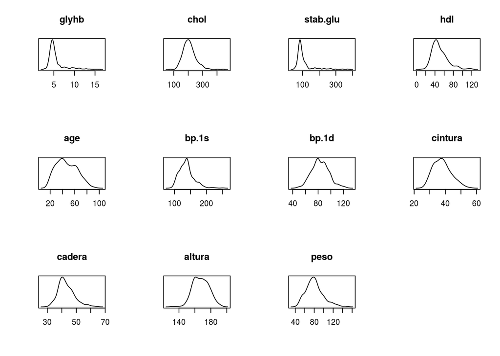

Gráficos de densidad mostrando la distribución de valores para cada una de las variables. Algunas de las variables, como *glyhb*, *stab.glu* y *bp.1s* parecen estar fuertemente sesgadas hacia valores bajos.

```r
par(mfrow=c(3,4))
for (i in 1:ncol(diabetes)){
plot(density(diabetes[,i]),
     main = colnames(diabetes[i]),
     xlab = "", ylab = "", yaxt = 'n')
}
```

## Ejercicio 1a. Ajustar un modelo lineal para explicar la variable hemoglobina glicosilada en función del resto de variables de la base de datos. Como el número de variables predictoras es elevado, investigar la posible multicolinealidad de este modelo de regresión.

Como primer paso, vamos a ajustar un modelo lineal con todas las variables predictoras

```r
hemo_mod <- lm(glyhb ~ ., data = diabetes)
summary(hemo_mod)
```

```
##
## Call:
## lm(formula = glyhb ~ ., data = diabetes)
##
## Residuals:
##     Min      1Q  Median      3Q     Max
## -7.9404 -0.7463 -0.1438  0.5107  9.6528
##
## Coefficients:
##              Estimate Std. Error t value Pr(>|t|)
## (Intercept) -1.004119   2.105648  -0.477 0.633740
## chol         0.006795   0.001802   3.772 0.000189 ***
## stab.glu     0.027511   0.001497  18.373  < 2e-16 ***
## hdl         -0.008132   0.004666  -1.743 0.082237 .
## age          0.010741   0.005782   1.857 0.064046 .
## bp.1s        0.002601   0.004778   0.544 0.586505
## bp.1d       -0.002957   0.007400  -0.400 0.689642
## cintura      0.034309   0.029918   1.147 0.252220
## cadera       0.010906   0.031044   0.351 0.725550
## altura       0.006587   0.009667   0.681 0.496058
## peso        -0.010538   0.010937  -0.963 0.335934
## ---
## Signif. codes:  0 '***' 0.001 '**' 0.01 '*' 0.05 '.' 0.1 ' ' 1
##
## Residual standard error: 1.437 on 366 degrees of freedom
## Multiple R-squared:  0.5897, Adjusted R-squared:  0.5784
## F-statistic: 52.59 on 10 and 366 DF,  p-value: < 2.2e-16
```

Llama la atención lo pequeños que son los valores de los coeficientes de los predictores. Esto puede deberse a que los valores que adoptan las variables predictoras son uno o dos órdenes de magnitud superiores a los valores que adopta la variable respuesta. Para trabajar con unos coeficientes que sean menos confusos a la vista, cambiaremos la escala de la respuesta multiplicándola por 10 y ajustando los datos a un nuevo modelo:

```r
hemo_mod <- lm(I(glyhb*10) ~ ., data = diabetes)
summary(hemo_mod)
```

```
##
## Call:
## lm(formula = I(glyhb * 10) ~ ., data = diabetes)
##
## Residuals:
##     Min      1Q  Median      3Q     Max
## -79.404  -7.463  -1.438   5.107  96.528
##
## Coefficients:
##              Estimate Std. Error t value Pr(>|t|)
## (Intercept) -10.04119   21.05648  -0.477 0.633740
## chol          0.06795    0.01802   3.772 0.000189 ***
## stab.glu      0.27511    0.01497  18.373  < 2e-16 ***
## hdl          -0.08132    0.04666  -1.743 0.082237 .
## age           0.10741    0.05782   1.857 0.064046 .
## bp.1s         0.02601    0.04778   0.544 0.586505
## bp.1d        -0.02957    0.07400  -0.400 0.689642
## cintura       0.34309    0.29918   1.147 0.252220
## cadera        0.10906    0.31044   0.351 0.725550
## altura        0.06587    0.09667   0.681 0.496058
## peso         -0.10538    0.10937  -0.963 0.335934
## ---
## Signif. codes:  0 '***' 0.001 '**' 0.01 '*' 0.05 '.' 0.1 ' ' 1
##
## Residual standard error: 14.37 on 366 degrees of freedom
## Multiple R-squared:  0.5897, Adjusted R-squared:  0.5784
## F-statistic: 52.59 on 10 and 366 DF,  p-value: < 2.2e-16
```

Comprobamos que, efectivamente, los coeficientes (y los errores estándar) de los predictores son diez veces mayores que en el modelo anterior, lo que los hace más cómodos a ojos humanos. Sin embargo el resto de valores (estadísticos, p-valores, R^2) permanecen inalterados.

Si seguimos examinando el sumario de los tests estadísticos a partir del modelo, vemos que el valor de R^2 ajustado no es pequeño, lo que apunta a que el modelo recoge gran parte de la variación en los datos. Sin embargo, tan sólo dos de las variables predictoras es significativa. Eso podría significar que no afectan a la variable respuesta o podría ser un síntoma de **colinealidad**. La colinealidad (o multicolinealidad) es la situación en la que una variable predictora es una combinación lineal de otras. Dicho de otra forma, tenemos varios predictores que están midiendo lo mismo y, por tanto, no son ortogonales entre ellos.

Una forma rápida de comprobar qué variables se correlacionan entre ellas es representarlas por pares en gráficas de nubes de puntos:

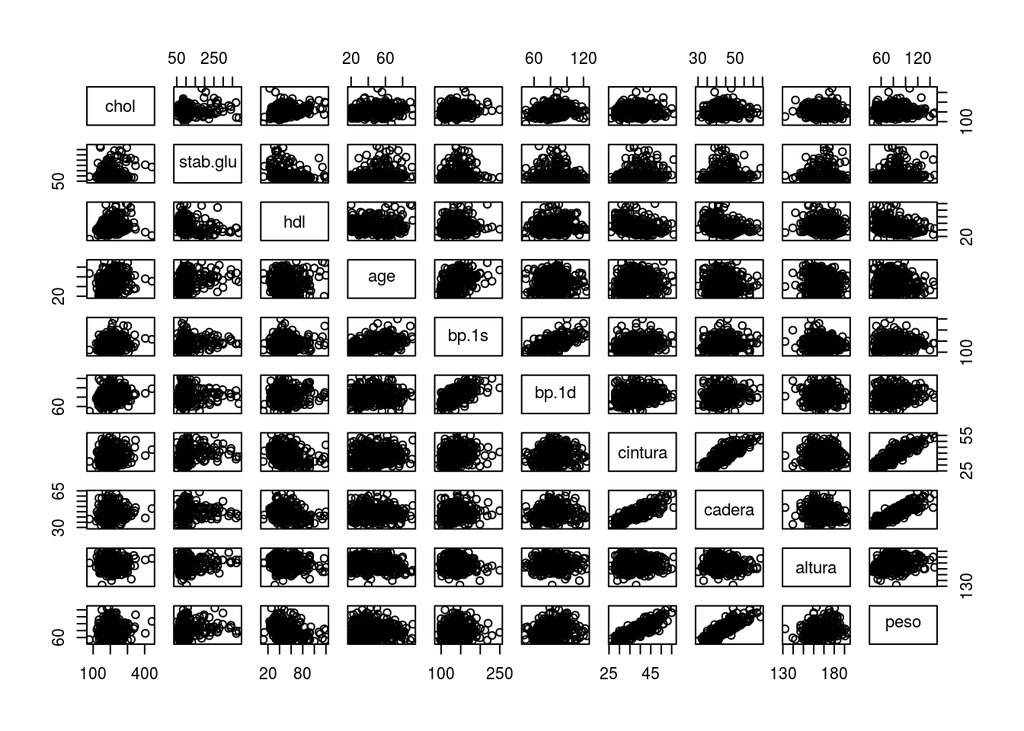

```r
pairs(diabetes[, -1])
```

A primera vista, las correlaciones más obvias son *cintura-cadera*, *cintura-peso* y *cadera-peso*. Nada sorprendente si tenemos en cuenta dónde se acumula la mayor proporción de grasa corporal. Otra correlación que parece clara es *bp.1s-bp.1d*. Correlaciones más difusas podrían ser *altura-peso*, *chol-stab.glu* y *chol-hdl*.

También podemos usar algo más preciso, como una **matriz de correlaciones**. Debido a la cantidad de variables, nos resultará más sencillo si la representamos en un gráfico de tipo mapa de calor:

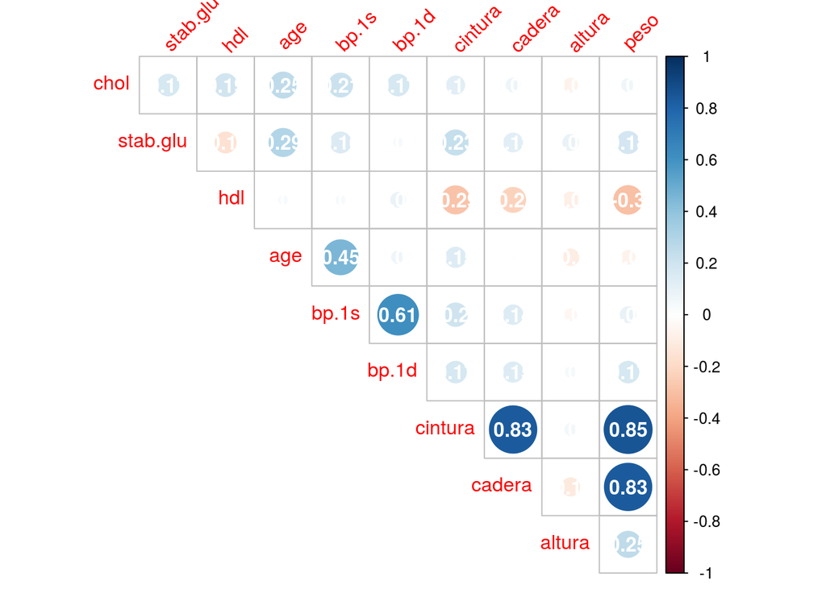

Matriz de correlaciones. El color azul indica correlación positiva, el color rojo correlación negativa. El tamaño de los círculos y la saturación del color son proporcionales al grado de correlación.

```r
corrplot::corrplot(
round(cor(diabetes[, -1]),2),
type = 'upper',
diag = FALSE,
addCoef.col = "white",
tl.srt = 45
)
```

En este gráfico vemos fácilmente que casi todos los pares de variables muestran algún tipo de correlación. Destacan, como veíamos antes, los pares de medidas físicas directamente relacionados con la acumulación de grasa ( *cintura-peso*, *cintura-cadera* y *cadera-peso*), y en menor medida los pares *bp.1d-bp.1s* y *age-bp.1s*. Si pensamos que variables muy correlacionadas están básicamente midiendo lo mismo, podemos simplificar el modelo eligiendo una única variable de cada grupo de variables relacionadas. Por ejemplo, para el grupo *cintura* - *peso* - *cadera* podemos elegir peso (la más fácil de medir); y del par *bp.1d-bp.1s* quedarnos sólo con *bp.1d*.

Si ajustamos los datos al nuevo modelo:

```r
# Modelo sin cintura, cadera, ni bp.1s
# Multiplicamos glyhb por 10 para obtener coeficientes más legibles
hemo_mod_simp <- lm(I(glyhb*10) ~ chol + stab.glu + hdl + age + bp.1d + altura + peso, data = diabetes)
summary(hemo_mod_simp)
```

```
##
## Call:
## lm(formula = I(glyhb * 10) ~ chol + stab.glu + hdl + age + bp.1d +
##     altura + peso, data = diabetes)
##
## Residuals:
##     Min      1Q  Median      3Q     Max
## -79.459  -7.314  -1.759   5.361  97.450
##
## Coefficients:
##              Estimate Std. Error t value Pr(>|t|)
## (Intercept)  6.305489  14.080631   0.448  0.65455
## chol         0.068300   0.017981   3.799  0.00017 ***
## stab.glu     0.276113   0.014931  18.493  < 2e-16 ***
## hdl         -0.086124   0.046399  -1.856  0.06423 .
## age          0.145189   0.048284   3.007  0.00282 **
## bp.1d       -0.001445   0.056747  -0.025  0.97970
## altura       0.010328   0.077663   0.133  0.89428
## peso         0.020886   0.045072   0.463  0.64335
## ---
## Signif. codes:  0 '***' 0.001 '**' 0.01 '*' 0.05 '.' 0.1 ' ' 1
##
## Residual standard error: 14.36 on 369 degrees of freedom
## Multiple R-squared:  0.587,  Adjusted R-squared:  0.5792
## F-statistic: 74.94 on 7 and 369 DF,  p-value: < 2.2e-16
```

El modelo simplificado tiene un ajuste casi idéntico al del modelo completo según el valor de R^2 ajustado. La significatividad de los predictores dentro del modelo no parece haber cambiado, excepto por *age*, aunque ya tenía un p-valor un poco por encima de 0.05 en el modelo completo. El único aspecto en el que se aprecian grandes cambios es en los valores de los coeficientes de los predictores que no eran significativos en el modelo completo.

## 1b. Sabemos que en lugar de altura y peso, el IMC es un mejor indicador de obesidad y por otro lado, la ratio cintura/cadera es también mejor predictor que cintura y cadera por separado. Calcular estas variables y ajustar un modelo incluyéndolas en lugar de las originales y comparar ambos modelos. ¿Es posible un contraste para decidir entre ambos modelos?

En primer lugar, calcularemos el IMC (masa/estatura^2) y la ratio cintura-cadera y las añadiremos al resto de datos:

```r
## IMC
# We divide altura by 100 to change its units to meters
# because it is usually encoded that way for IMC
diabetes$imc <- diabetes$peso/(diabetes$altura/100)^2

## Ratio cintura/cadera
diabetes$ratiocc <- diabetes$cintura/diabetes$cadera
```

Y en segundo lugar, ajustamos los datos al modelo que tiene en cuenta el IMC y la ratio cintura/cadera:

```r
hemo_mod_imc <- lm(I(glyhb*10) ~ chol + stab.glu + hdl + age + bp.1s + bp.1d + ratiocc + imc, data = diabetes)
summary(hemo_mod_imc)
```

```
##
## Call:
## lm(formula = I(glyhb * 10) ~ chol + stab.glu + hdl + age + bp.1s +
##     bp.1d + ratiocc + imc, data = diabetes)
##
## Residuals:
##     Min      1Q  Median      3Q     Max
## -78.586  -7.218  -1.592   5.251  97.191
##
## Coefficients:
##             Estimate Std. Error t value Pr(>|t|)
## (Intercept)  0.92254   10.79735   0.085 0.931957
## chol         0.06765    0.01798   3.763 0.000195 ***
## stab.glu     0.27556    0.01483  18.586  < 2e-16 ***
## hdl         -0.08230    0.04635  -1.776 0.076614 .
## age          0.11490    0.05640   2.037 0.042359 *
## bp.1s        0.03258    0.04741   0.687 0.492443
## bp.1d       -0.03407    0.07347  -0.464 0.643158
## ratiocc      8.21814   10.75753   0.764 0.445391
## imc          0.04256    0.11843   0.359 0.719550
## ---
## Signif. codes:  0 '***' 0.001 '**' 0.01 '*' 0.05 '.' 0.1 ' ' 1
##
## Residual standard error: 14.36 on 368 degrees of freedom
## Multiple R-squared:  0.5881, Adjusted R-squared:  0.5791
## F-statistic: 65.67 on 8 and 368 DF,  p-value: < 2.2e-16
```

¿Cómo decidir entre ambos modelos? En primer lugar, comprobaremos si son equivalentes. A primera vista, el valor de R^2 ajustado es muy parecido:

```r
c('modelo original' = summary(hemo_mod)$adj.r.squared, 'modelo modificado' = summary(hemo_mod_imc)$adj.r.squared)
```

```
##   modelo original modelo modificado
##         0.5784492         0.5791237
```

Seguidamente contrastaremos ambos modelos mediante un test *F*. A primera vista podríamos pensar que los modelos no están anidados porque las variables *IMC* y *ratio* no están en el modelo completo, y que tal contraste no es posible. Sin embargo, las variables *IMC* y *ratio* son combinaciones lineales de variables que sí están en el modelo completo, por tanto el contraste mediante un test *F* tiene sentido.

Si los comparamos mediante ANOVA:

```r
anova(hemo_mod_imc, hemo_mod)
```

```
## Analysis of Variance Table
##
## Model 1: I(glyhb * 10) ~ chol + stab.glu + hdl + age + bp.1s + bp.1d +
##     ratiocc + imc
## Model 2: I(glyhb * 10) ~ chol + stab.glu + hdl + age + bp.1s + bp.1d +
##     cintura + cadera + altura + peso
##   Res.Df   RSS Df Sum of Sq      F Pr(>F)
## 1    368 75892
## 2    366 75600  2    291.49 0.7056 0.4945
```

Vemos que, estadísticamente, ambos modelos son equivalentes (p-valor > 0.05). No parece haber razón para elegir uno sobre el otro.

## 1c. A partir del modelo mejorado del apartado anterior, ajustar un modelo de regresión con componentes principales y determinar el número de componentes óptimo que minimice el error cuadrático medio de predicción (o su raíz cuadrada).

Volvemos primeramente a examinar los valores de las variables para determinar si es necesario realizar algún tipo de escalado:

```r
# database with imc and ratiocc minus the variables
# included in these last variables
diabetes_modif <- diabetes[, ! names(diabetes) %in% c("cintura", "cadera", "altura", "peso")]
head(diabetes_modif)
```

```
##   glyhb chol stab.glu hdl age bp.1s bp.1d      imc   ratiocc
## 1  4.31  203       82  56  46   118    59 22.15085 0.7631579
## 2  4.44  165       97  24  29   112    68 37.45286 0.9583333
## 3  4.64  228       92  37  58   190    92 48.41375 0.8596491
## 4  4.63   78       93  12  67   110    50 18.65459 0.8684211
## 5  7.72  249       90  28  64   138    80 27.84977 1.0731707
## 6  4.81  248       94  69  34   132    86 26.52316 0.8571429
```

Contemplamos diferencias de hasta tres órdenes de magnitud entre algunas variables (e.g. entre *chol* y *ratiocc*). Esta diferencia haría que las variables con valores mayores estuvieran sobrerrepresentadas en las componentes principales al tener mayor varianza. Para evitar ese sesgo convertiremos los valores de todas las variables a unidades estándar (restando su media y dividiendo por su desviación estándar); y calcularemos las componentes principales a partir de esos valores:

```r
PC_diabetes_modif <- prcomp(diabetes_modif[, 2:9], scale = TRUE)
summary(PC_diabetes_modif)
```

```
## Importance of components:
##                          PC1    PC2    PC3    PC4     PC5     PC6     PC7
## Standard deviation     1.475 1.1908 1.0922 0.9612 0.88783 0.80584 0.76758
## Proportion of Variance 0.272 0.1772 0.1491 0.1155 0.09853 0.08117 0.07365
## Cumulative Proportion  0.272 0.4493 0.5984 0.7139 0.81240 0.89358 0.96722
##                            PC8
## Standard deviation     0.51207
## Proportion of Variance 0.03278
## Cumulative Proportion  1.00000
```

Vemos que en este caso la varianza está muy repartido. Necesitamos hasta 5 componentes principales para reunir al menos el 80% de la varianza, y 7 para reunir más del 90% de la misma.

Por curiosidad, veamos cuál es la aportación de las variables a cada componente principal:

```r
round(PC_diabetes_modif$rotation, digits = 2)
```

```
##            PC1   PC2   PC3   PC4   PC5   PC6   PC7   PC8
## chol      0.34 -0.21  0.25 -0.67  0.20  0.03  0.53 -0.06
## stab.glu  0.32  0.35  0.29 -0.19 -0.59  0.49 -0.25 -0.01
## hdl      -0.02 -0.65  0.25 -0.18  0.16  0.10 -0.66 -0.05
## age       0.45  0.02  0.43  0.23 -0.08 -0.60 -0.07  0.44
## bp.1s     0.54 -0.22 -0.23  0.28 -0.16 -0.14  0.02 -0.69
## bp.1d     0.40 -0.30 -0.53  0.12  0.00  0.37  0.07  0.56
## imc       0.19  0.37 -0.48 -0.51  0.14 -0.35 -0.44  0.01
## ratiocc   0.30  0.36  0.21  0.25  0.73  0.33 -0.12 -0.09
```

Para decidir cuántas componentes principales incluir como predictores en el modelo, buscaremos la combinación de predictores que ofrece predicciones con menor RMSE (raíz del error cuadrático medio). El método que usaremos para dividir las observaciones del set de datos en entrenamiento y validación de los modelos será el de validación cruzada (usando 10 segmentos aleatorios de los datos). Utilizaremos funciones del paquete `pls` del lenguaje **R**:

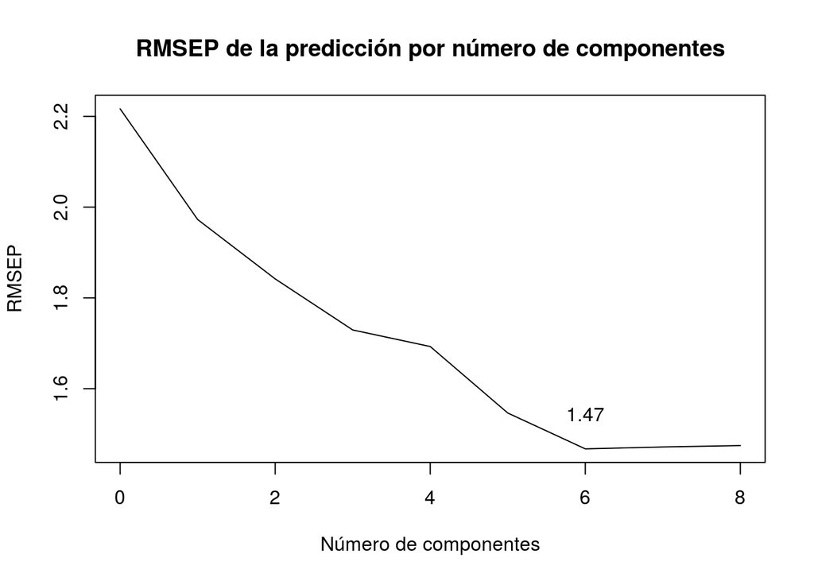

Representación de la raíz del error cuadrático medio según el número de componentes usado en la predicción de la variable glyhb. El objetivo es averiguar cuántos componentes ofrecen el menor error medio.

```r
# Regresion sobre componentes principales
set.seed(12021021)
PC_reg <- pcr(glyhb ~ ., data = diabetes_modif,
              scale = TRUE,
              validation = "CV",
              ncomp = 8)
# Estimate the RMSEP by cross-validation
PC_reg_CV <- RMSEP(PC_reg, estimate = "CV")
# Components at which RMSEP in minimum
min_comp <- which.min(PC_reg_CV$val)
# Plot
plot(PC_reg_CV,
     main = "RMSEP de la predicción por número de componentes",
     xlab = "Número de componentes")
text(min_comp-1, # x coord is components
     y = round(PC_reg_CV$val[min_comp], digits = 2)*1.05, # y coord is RMSEP plus 10%
     labels = round(PC_reg_CV$val[min_comp],2)) # text is RMSEP value
```

Vemos con bastante claridad en el gráfico que 6 es la cantidad de componentes con la que obtenemos mejores predicciones de los valores de la variable respuesta *glyhb* en nuestro set de datos.

Finalmente, una vez decididas la cantidad de componentes principales óptima según nuestro set de datos, procedemos a reajustar el modelo de regresión:

```r
set.seed(5500)
PC_reg_mod <- pcr(glyhb ~ ., data = diabetes_modif,
              scale = TRUE,
              validation = "CV",
              ncomp = min_comp-1)
```

## 1d. Con el mismo modelo, ajustar un modelo de regresión por mínimos cuadrados parciales (PLS) y determinar el número óptimo de componentes.

Aunque el método es diferente, los pasos que seguiremos serán similares a los del apartado anterior utilizando en esta ocasión la función `plsr()`:

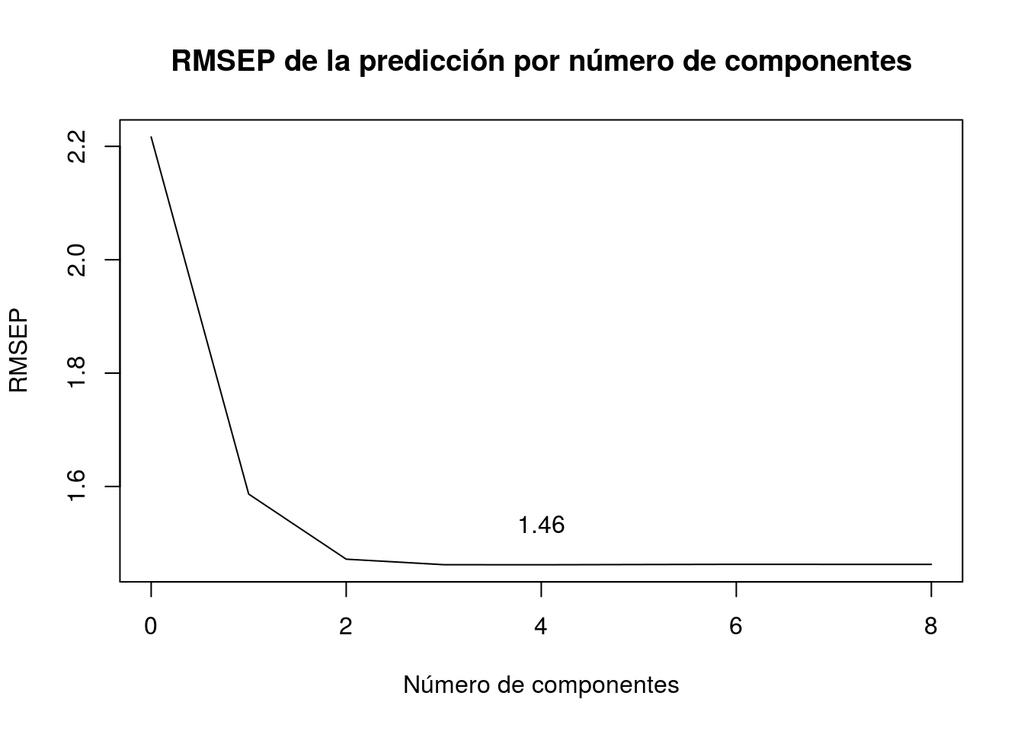

Representación de la raíz del error cuadrático medio según el número de componentes usado en la predicción de la variable glyhb mediante diferentes modelos generados por regresión de mínimos cuadrados parciales. El objetivo es averiguar cuántos componentes ofrecen el menor error medio.

```r
set.seed(90012)
# Compute the PLS models
PLS_reg <- plsr(glyhb ~ ., data = diabetes_modif,
                scale = TRUE,
                validation = "CV")
# Estimate the RMSEP by cross-validation
PLS_reg_CV <- RMSEP(PLS_reg, estimate = "CV")
# Components at which RMSEP in minimum
min_comp <- which.min(PLS_reg_CV$val)
# Plot
plot(PLS_reg_CV,
     main = "RMSEP de la predicción por número de componentes",
     xlab = "Número de componentes")
text(min_comp-1, # x coord is components
     y = round(PLS_reg_CV$val[min_comp], digits = 2)*1.05, # y coord is RMSEP plus 10%
     labels = round(PLS_reg_CV$val[min_comp],2)) # text is RMSEP value
```

Vemos en el gráfico que ha quedado señalado en 4 componentes la cantidad con la que obtenemos mejores predicciones de los valores de la variable respuesta *glyhb* en nuestro set de datos.

## 1e. Ajustar también un modelo de regresión RIDGE y, utilizando validación cruzada, determinar el parámetro óptimo.

El modelo de regresión ridge se diferencia del modelo de mínimos cuadrados en que utiliza un parámetro $\lambda$ que penaliza los estimadores $\hat \beta$ de los predictores, generando estimadores menores de los que se obtendrían por mínimos cuadrados. Es especialmente útil cuando la varianza en los datos es alta.

Para seleccionar el valor óptimo de $\lambda$ mediante validación cruzada usaremos la función `cv.glmnet()` (que además escala y centra los datos de forma automática):

```r
# Sequence of lambda values to try
la_va <- 10^seq(2, -2, length = 100)
# Set train and test subsets of data
set.seed(391)
diabetes_train <- sample(1:nrow(diabetes_modif), nrow(diabetes_modif)/2) # half the data for each set
diabetes_test <- -diabetes_train

# Compute the lambda that gives a minimum mean cross-validated error
ridge_diabetes <- cv.glmnet(as.matrix(diabetes_modif[diabetes_train, -1]), # predictors)
                            diabetes_modif[diabetes_train, 1], #response
                            alpha = 0, # ridge penalty passed to glmnet function
                            lambda = la_va) # user-provided lambda values

###Notes###
# cv.glmnet expects a matrix of predictors, not a data frame
# https://stackoverflow.com/questions/8457624/r-glmnet-list-object-cannot-be-coerced-to-type-double
```

El valor de $\lambda$ que resulta en el menor error durante validación cruzada en el set de entrenamiento es 0.071, y el valor de ese error es 2.0544989.

Si probamos ese valor de $\lambda$ en el subset de validación:

```r
# Predict response from test subset
ridge_diabetes_predic <- predict(ridge_diabetes, #fitted glmnet object
                                 s = ridge_diabetes$lambda.min, # lambda
                                 newx = as.matrix(diabetes_modif[diabetes_test, -1] # matrix of new values for prediction
                                                  ))

# Compute MSE error for test set
mean((ridge_diabetes_predic - diabetes_modif[diabetes_test, 1])^2)
```

```
## [1] 2.265266
```

Los errores de ambos sets son bastante parecidos.

Finalmente, volvemos a ajustar el modelo de regresión ridge sobre el conjunto completo de datos usando el valor de $\lambda$ elegido por validación cruzada y examinamos los coeficientes calculados para los predictores:

```r
# Fit the model
ridge_diabetes_full <- glmnet(as.matrix(diabetes_modif[, -1]), # predictores
                              diabetes_modif[, 1], # respuesta
                              alpha = 0, # ridge penalty
                              lambda = la_va)

# Predict the outcomes
predict(ridge_diabetes_full,
        type = "coefficients", # compute the coefficients at values for s
        s = ridge_diabetes$lambda.min)[1:9,]
```

```
##  (Intercept)         chol     stab.glu          hdl          age
##  0.093031824  0.006677772  0.026645832 -0.008277169  0.011893340
##        bp.1s        bp.1d          imc      ratiocc
##  0.003315765 -0.003317158  0.004907485  0.894917041
```

Parece que el predictor más influyente es la **ratio cintura-cadera**. Al resto de predictores se les asignan coeficientes uno y hasta dos órdenes de magnitud menores.

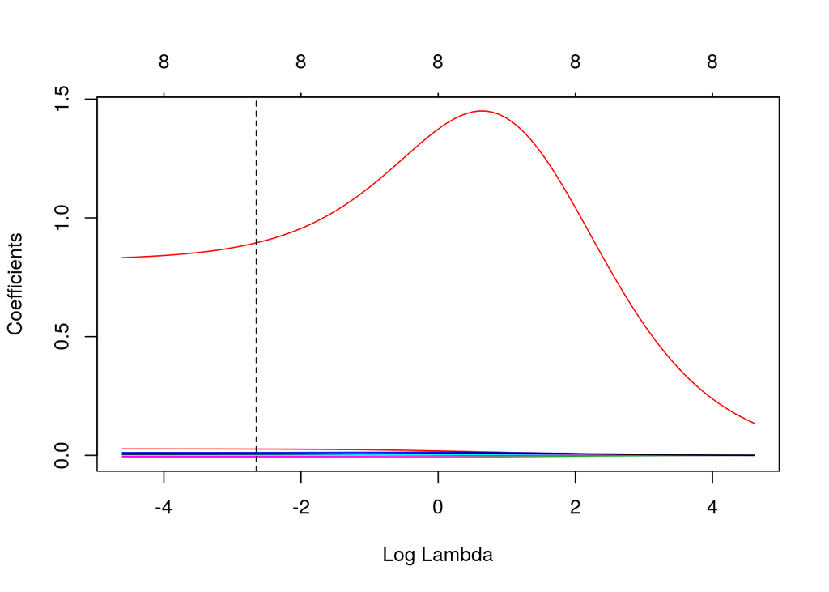

Gráfica de valores de log(lambda) frente a coeficientes de los predictores. La línea roja representa el estimador del coeficiente de la variable `ratiocc`; la línea vertical intermitente marca el valor de log(lambda) que minimiza la media de errores al cuadrado (MSE).

```r
plot(ridge_diabetes_full, xvar = 'lambda')
abline(v=log(ridge_diabetes$lambda.min), lty = 2)
```

## 1f. Ajustar por último un modelo de regresión LASSO y, con validación cruzada, hallar el parámetro óptimo.

El método de regresión *lasso* "permite" eliminar variables del modelo de regresión, simplificándolo. Al igual que la regresión ridge, hace menguar los coeficientes estimados de los predictores pero, a diferencia de aquella, dichos coeficientes pueden llegar a ser igual a cero, efectivamente eliminando la variable del modelo. En general, el método *lasso* es más útil cuando la respuesta depende de un pequeño número de predictores con coeficientes relativamente grandes y el resto de predictores tienen coeficientes pequeños o iguales a cero. El método *ridge* es más adecuado cuando la respuesta depende de muchos predictores con coeficientes de tamaños similares.

Podemos utilizar la función `glmnet()` igual que hicimos en el apartado anterior para la regresión por el método ridge. En primer lugar, usaremos validación cruzada sobre el grupo de datos de entrenamiento para decidir el valor de $\lambda$ más adecuado:

```r
set.seed(391)

# Compute the lambda that gives a minimum mean cross-validated error
lasso_diabetes <- cv.glmnet(as.matrix(diabetes_modif[diabetes_train, -1]), # predictors)
                            diabetes_modif[diabetes_train, 1], #response
                            alpha = 1, # lasso penalty passed to glmnet function
                            lambda = la_va)

lasso_lambda <- c(ridge_diabetes$lambda.min, # Lambda value
                  ridge_diabetes$cvm[which.min(ridge_diabetes$cvm)]) # Minimu average error
```

```r
# Predict response from test subset
lasso_diabetes_predic <- predict(lasso_diabetes, #fitted glmnet object
                                 s = lasso_lambda[1], # lambda
                                 newx = as.matrix(diabetes_modif[diabetes_test, -1] # matrix of new values for prediction
                                                  ))

# Compute MSE error for test set
mean((lasso_diabetes_predic - diabetes_modif[diabetes_test, 1])^2)
```

```
## [1] 2.241851
```

Finalmente, volvemos a ajustar el modelo de regresión lasso sobre el conjunto completo de datos usando el valor de $\lambda$ elegido por validación cruzada y examinamos los coeficientes calculados para los predictores:

```r
# Fit the model
lasso_diabetes_full <- glmnet(as.matrix(diabetes_modif[, -1]), # predictores
                              diabetes_modif[, 1], # respuesta
                              alpha = 1, # lasso penalty passed to glmnet function
                            lambda = la_va)

# Predict the outcomes
predict(lasso_diabetes_full,
        type = "coefficients", # compute the coefficients at values for s
        s = lasso_diabetes$lambda.min)[1:9,]
```

```
##   (Intercept)          chol      stab.glu           hdl           age
##  0.6989170996  0.0057856317  0.0272478391 -0.0058274881  0.0112576440
##         bp.1s         bp.1d           imc       ratiocc
##  0.0007549475  0.0000000000  0.0000000000  0.4839069921
```

Vemos que dos de los ocho predictores tienen estimadores de coeficiente igual a cero, lo que los deja fuera del modelo final y **nos sugiere un modelo simplificado de seis variables predictoras**.

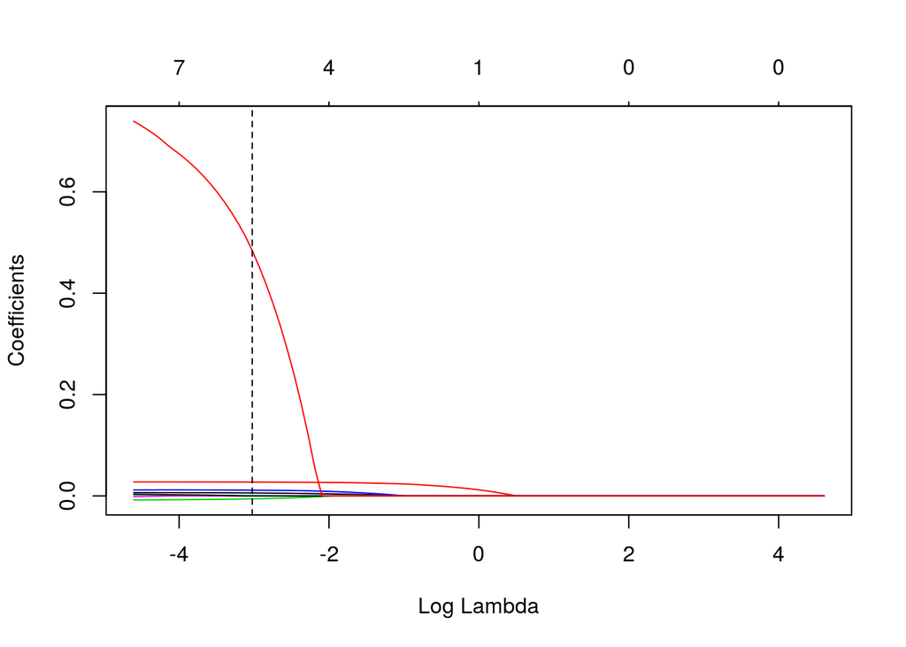

Gráfica de valores de log(lambda) frente a coeficientes de los predictores. La línea roja representa el estimador del coeficiente de la variable `ratiocc`; la línea vertical intermitente marca el valor de log(lambda) que minimiza la media de errores al cuadrado (MSE).

```r
plot(lasso_diabetes_full, xvar = 'lambda')
abline(v=log(lasso_diabetes$lambda.min), lty = 2)
```

Podemos ver en la gráfica cómo, a medida que aumenta lambda, los estimadores para los coeficientes van progresivamente igualándose a cero. Sin embargo, en la gráfica equivalente para la regresión por el métido ridge, los estimadores nunca llegan a igualarse a cero sino que sólo se aproximan a ese valor sin alcanzarlo.

# Ejercicio 2. Base de datos `gas_pressure.txt`

Como preparación al ejercicio, cargaremos los datos a memoria y examinaremos las características y estructura de los mismos.

```r
# Reading and loading data from file gas_pressure.txt
gas_pressure <- read.table("./data/gas_pressure.txt",
           header = TRUE
           )

kable(
  head(gas_pressure),
  caption = "Ejemplo de las primeras seis observaciones en la base de datos `gas_pressure`.",
  align = 'c'
)
```

Ejemplo de las primeras seis observaciones en la base de datos `gas_pressure`.

| pressure | temp |
| --- | --- |
| 91.423 | 21.602 |
| 91.695 | 21.448 |
| 98.883 | 23.323 |
| 97.324 | 22.971 |
| 107.620 | 25.854 |
| 108.112 | 25.609 |

Si examinamos la estructura de la base de datos:

```r
str(gas_pressure)
```

```
## 'data.frame':    40 obs. of  2 variables:
##  $ pressure: num  91.4 91.7 98.9 97.3 107.6 ...
##  $ temp    : num  21.6 21.4 23.3 23 25.9 ...
```

Vemos que se compone de 40 observaciones y 2 variables. Todas las variables han sido correctamente identificadas como numéricas.

Finalmente, una forma rápida de buscar valores anómalos y valores ausentes es mediante el resumen numérico:

```r
summary(gas_pressure)
```

```
##     pressure           temp
##  Min.   : 91.42   Min.   :21.45
##  1st Qu.:139.52   1st Qu.:34.05
##  Median :186.02   Median :46.30
##  Mean   :181.87   Mean   :44.45
##  3rd Qu.:224.03   3rd Qu.:54.69
##  Max.   :280.35   Max.   :68.77
```

No parece haber valores anómalos (entendidos como exageradamente elevados o exageradamente pequeños) en ninguna de las variables. Aunque es difícil de asegurar, ya que no estoy familiarizado con estas variables. En cualquier caso, no parece haber ningún valor que destaque. Tampoco se ha detectado que falte ningún valor.

Finalmente, podríamos incluir un resumen gráfico de las variables para hacernos una idea de la distribución de valores en cada una:

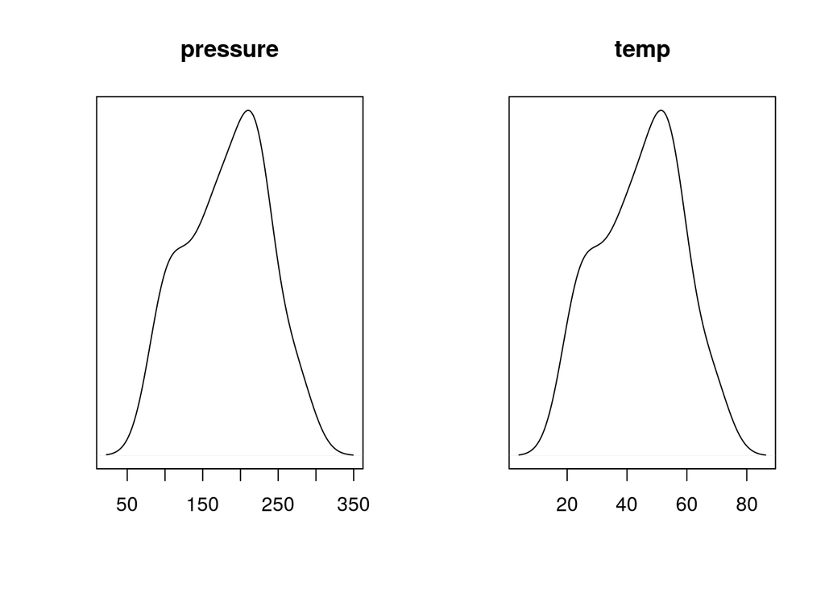

Gráficos de densidad mostrando la distribución de valores para cada una de las variables. Ambas variables tienen una distribución similar a la normal. Resulta notable que ambos gráficos presentan el mismo perfil.

```r
par(mfrow=c(1,2))
for (i in 1:ncol(gas_pressure)){
plot(density(gas_pressure[,i]),
     main = colnames(gas_pressure[i]),
     xlab = "", ylab = "", yaxt = 'n')
}
```

## 2a. Mostrar el problema de heterocedasticidad en la regresión lineal con la presión como variable respuesta y la temperatura como explicativa. Realizar un gráfico y un test apropiados.

En primer lugar, ajustamos los datos a un modelo lineal:

```r
gas_mod <- lm(pressure ~ temp, data =  gas_pressure)
sumary(gas_mod)
```

```
##             Estimate Std. Error t value Pr(>|t|)
## (Intercept)   7.9935     2.9619  2.6988  0.01033
## temp          3.9120     0.0638 61.3168  < 2e-16
##
## n = 40, p = 2, Residual SE = 5.40971, R-Squared = 0.99
```

Si representamos en una gráfica los valores ajustados frente a los residuos:

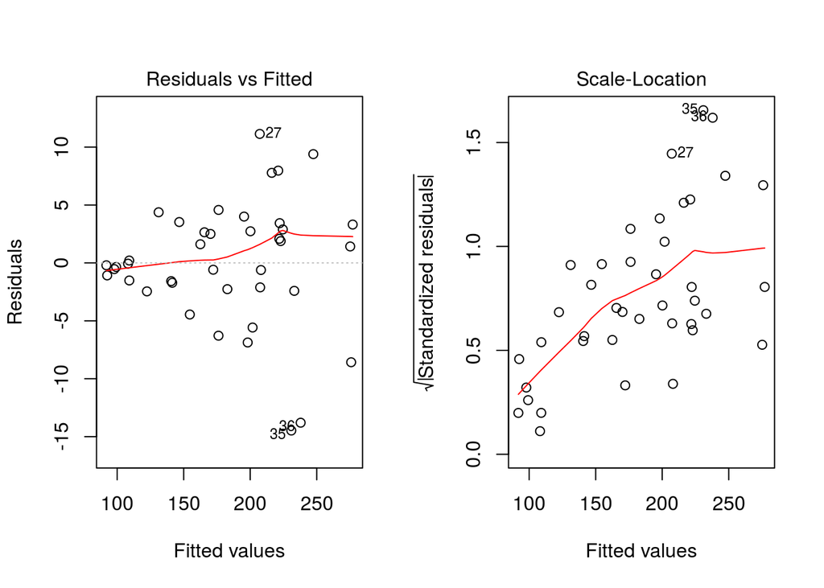

(izq.) Residuos frente a valores ajustados. Obśervese la forma de embudo que adquiere la nube de puntos, creciendo hacia los valores ajustados mayores. (der.) Raíz cuadrada de los residuos estandarizados frente a valores ajustados. Obsérvese que la nube de puntos se ajusta a una diagonal creciente en la dirección de los valores ajustados mayores.

```r
par(mfrow = c(1,2))
plot(gas_mod, which = c(1,3))
```

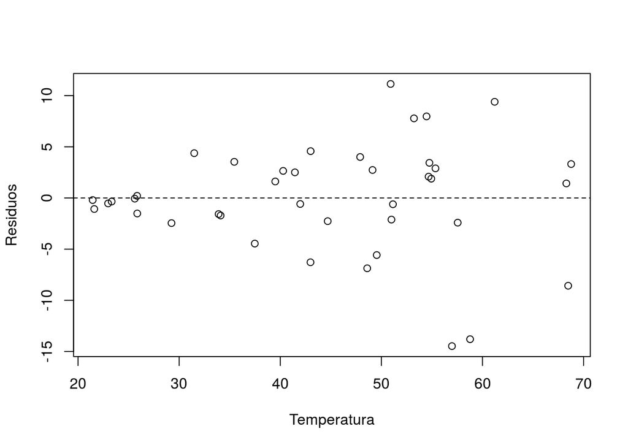

```r
plot(gas_pressure$temp,
     gas_mod$residuals,
     ylab = "Residuos",
     xlab = "Temperatura")
abline(h=0, lty=2)
```

El tamaño de los residuos parece aumentar con el valor de la variable *temp*, lo que apunta a que la varianza no es la misma en todo el rango de datos sino que aumenta con el propio valor de estos.

Además de gráficamente podemos hacer un estudio numérico comprobando si los errores de la regresión son independientes o si están relacionados con los valores ajustados al modelo:

```r
sumary(lm(sqrt(abs(residuals(gas_mod)))~fitted(gas_mod)))
```

```
##                   Estimate Std. Error t value  Pr(>|t|)
## (Intercept)     -0.0152076  0.4114039 -0.0370    0.9707
## fitted(gas_mod)  0.0097923  0.0021735  4.5054 6.141e-05
##
## n = 40, p = 2, Residual SE = 0.72096, R-Squared = 0.35
```

El estimador del coeficiente de los valores ajustados es significativo, y el valor de R^2 - siendo bajo - es mucho mayor de lo que esperaríamos si el valor de los errores fuera aleatorio. Por esto, vemos que hay relación entre el valor de la variable *temp* y el valor de los errores de la regresión, apuntando a que la varianza no es homogénea sino que depende de aquellos valores.

## 2b. Probar entre el conjunto de transformaciones Box-Cox si alguna mejora la heterocedasticidad de la regresión lineal simple.

El método Box-Cox sirve para encontrar una transformación de las variables que sirva para encontrar un mejor ajuste de los datos. Se trata de encontrar un estimador ($\hat \lambda$) al que elevaremos nuestra variable. Para calcular ese estimador usaremos la función `BoxCoxTrans()` del paquete `caret`.

```r
BoxCoxTrans(gas_pressure$temp)
```

```
## Box-Cox Transformation
##
## 40 data points used to estimate Lambda
##
## Input data summary:
##    Min. 1st Qu.  Median    Mean 3rd Qu.    Max.
##   21.45   34.05   46.30   44.45   54.69   68.77
##
## Largest/Smallest: 3.21
## Sample Skewness: -0.111
##
## Estimated Lambda: 1
## With fudge factor, no transformation is applied
```

```r
BoxCoxTrans(gas_pressure$pressure)
```

```
## Box-Cox Transformation
##
## 40 data points used to estimate Lambda
##
## Input data summary:
##    Min. 1st Qu.  Median    Mean 3rd Qu.    Max.
##   91.42  139.52  186.02  181.87  224.03  280.35
##
## Largest/Smallest: 3.07
## Sample Skewness: -0.118
##
## Estimated Lambda: 1
## With fudge factor, no transformation is applied
```

Los tests sugieren que no lograremos un mejor ajuste transformando ninguna de las dos variables.

También podemos optar por una representación gráfica, incluyendo intervalos de confianza para lambda:

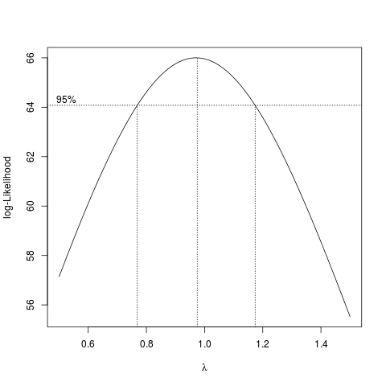

Bondad de ajuste frente a lambda estimada para la variable respuesta pressure. Las líneas punteadas delimitan el intervalo de confianza del 95%. El valor 1 está incluido dentro del intevalo, lo que señala a que no hay razón suficiente para realizar la transformación.

```r
interfile <- "images/boxcox_pressure.png"

#save grid of graphs
if(file.exists(interfile)){
  knitr::include_graphics(interfile) # Draw image
}else{
  png("./images/boxcox_pressure.png")
boxcox(gas_mod, lambda=seq(0.5,1.5,by=0.1)) # Generate plot
dev.off() # close device
knitr::include_graphics(interfile) # Draw image
}
```

```r
## For some reason, if the graph is generated on the fly while knitting execution ends with an error. Pre-generating the plot
## as a png and loading it during knitting is a work-around that prevents it.
```

## 2c. Como sabemos que la presión de un gas en un tanque es proporcional a la temperatura, calcular la regresión si la variable respuesta es la inversa de la presión. Estudiar la diagnosis de este modelo. ¿Aparece un problema estructural?

```r
gas_mod_inv_p <- lm(1/pressure ~ temp, data = gas_pressure)
sumary(gas_mod_inv_p)
```

```
##                Estimate  Std. Error t value  Pr(>|t|)
## (Intercept)  1.2729e-02  3.6232e-04  35.132 < 2.2e-16
## temp        -1.4955e-04  7.8043e-06 -19.163 < 2.2e-16
##
## n = 40, p = 2, Residual SE = 0.00066, R-Squared = 0.91
```

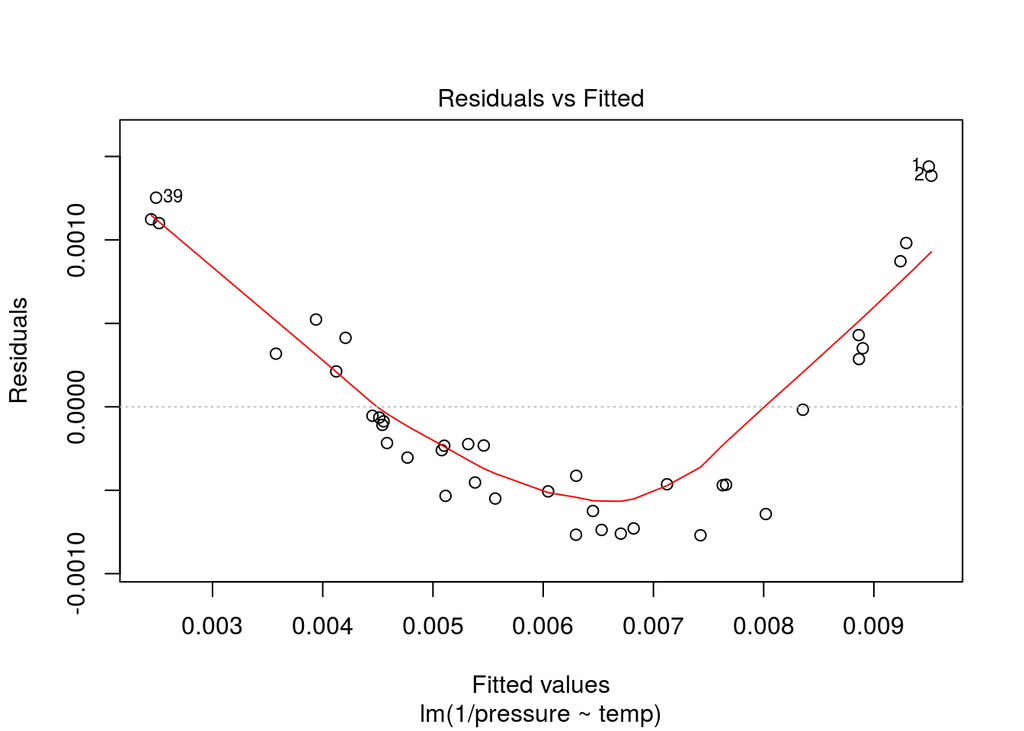

Residuos frente a valores ajustados. Se aprecia claramente que el valor de los residuos sigue una estructura subyacente.

```r
plot(gas_mod_inv_p, which = 1)
```

**Finalmente, además de esta transformación para la respuesta, también hay que transformar la variable regresora. Probar con las transformaciones más habituales y elegir el mejor modelo.**

Las transformaciones más habituales son la cuadrática, la raíz cuadrada y la inversa. Compararemos cómo afecta aplicar cada transformación a la variable predictora:

```r
gas_mod_inv_p2 <- lm(1/pressure ~ I(1/temp), data = gas_pressure)
gas_mod_inv_p3 <- lm(1/pressure ~ I(temp^2), data = gas_pressure)
gas_mod_inv_p4 <- lm(1/pressure ~ sqrt(temp), data = gas_pressure)
```

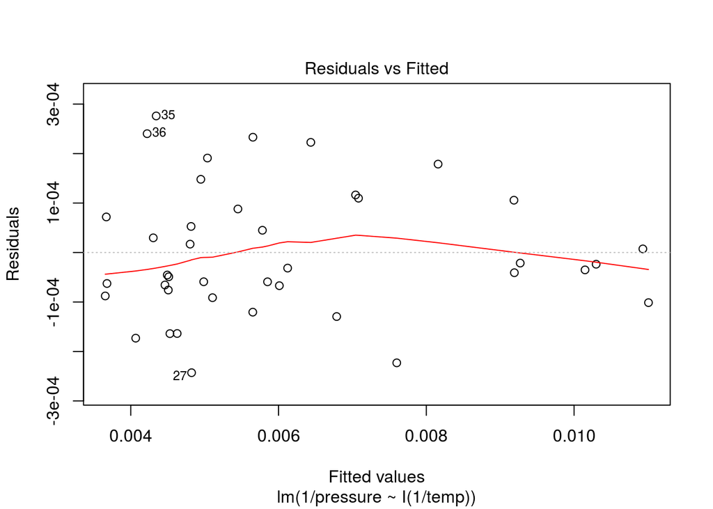

```r
plot(gas_mod_inv_p2, which = 1)
```

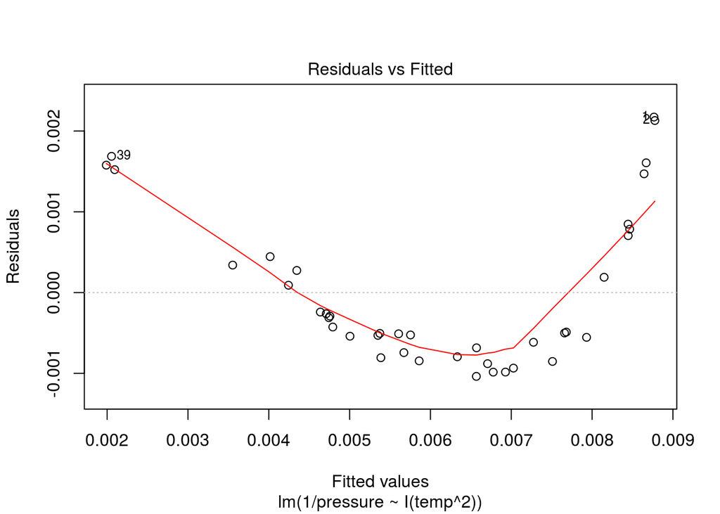

```r
plot(gas_mod_inv_p3, which = 1)
```

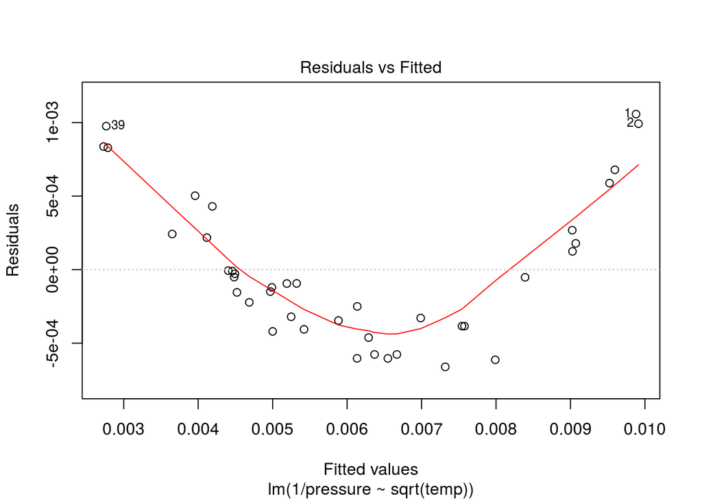

```r
plot(gas_mod_inv_p4, which = 1)
```

De las tres transformaciones aplicadas, invertir los valores de las variables respuesta y la variable predictora es la transformación que alivia en mayor medida el problema de los errores de regresión no aleatorios (ver la primera de las tres gráficas anteriores).

## 2d. Ahora vamos con la regresión ponderada o WLS

**Construimos una columna de datos con las temperaturas redondeadas de forma que los valores se repitan.**

Esto lo hacemos para generar grupos de datos. Posteriormente calcularemos la varianza en cada grupo de datos, ya que anteriormente vimos que la varianza no es homogénea y diferentes zonas del rango de temperaturas corresponden a diferentes varianzas.

```r
temp_r <- 3 * round(gas_pressure$temp/3)
## Division and posterior multiplication by three
## has the effect of augmenting granularity
# with more repeated values (wider groups)

grupos <- length(unique(temp_r))
```

En total, dividiremos los datos en 15 grupos según el valor de temperatura.

**Calcularemos la desviación estándar de la presión en cada grupo de temperaturas redondeadas.**

```r
# Indexes for ordering the data
# not relevant in this case, since the values of temperature are already
# somewhat ordered and get completely ordered when rounded
orden <- order(temp_r)

# Order the original data by the index above
gas_pressure_ord <- gas_pressure[orden,]

# Compute the mean of the predictor for each group
temperature_mean <- unlist(lapply(split(gas_pressure_ord$temp, temp_r[orden]), mean))
# Compute variance of the response for each group
pressure_var <- unlist(lapply(split(gas_pressure_ord$pressure, temp_r[orden]), var))
```

Si suponemos que la varianza sigue el modelo
$$\log(\sigma_i^2) = \log(\gamma_1) + \gamma_2 · \log(temp_i)$$

```r
gas_pressure_logmod <- lm(log(pressure_var) ~ log(temperature_mean))
summary(gas_pressure_logmod)
```

```
##
## Call:
## lm(formula = log(pressure_var) ~ log(temperature_mean))
##
## Residuals:
##    Min     1Q Median     3Q    Max
## -7.965 -1.198  0.739  1.367  4.806
##
## Coefficients:
##                       Estimate Std. Error t value Pr(>|t|)
## (Intercept)            -19.981      8.530  -2.342   0.0372 *
## log(temperature_mean)    5.853      2.304   2.541   0.0259 *
## ---
## Signif. codes:  0 '***' 0.001 '**' 0.01 '*' 0.05 '.' 0.1 ' ' 1
##
## Residual standard error: 3.059 on 12 degrees of freedom
##   (1 observation deleted due to missingness)
## Multiple R-squared:  0.3498, Adjusted R-squared:  0.2956
## F-statistic: 6.456 on 1 and 12 DF,  p-value: 0.02589
```

**$\gamma_1$:** -19.9808199  
**$\gamma_2$:** 5.8531797

## 2e. Tomamos un valor entero *g* próximo a $\gamma_2$ y consideramos los pesos como $\omega_i \approx temp^{-g}$. Calcular la regresión ponderada con esos pesos.

```r
# Choose gamma 2
g <- round(coef(gas_pressure_logmod)[[2]])

# Fit to weighted model
gas_pressure_wlm <- lm(pressure ~ temp, data = gas_pressure, weights = gas_pressure$temp^-g)
summary(gas_pressure_wlm)
```

```
##
## Call:
## lm(formula = pressure ~ temp, data = gas_pressure, weights = gas_pressure$temp^-g)
##
## Weighted Residuals:
##        Min         1Q     Median         3Q        Max
## -8.656e-05 -3.830e-05  6.763e-06  3.359e-05  1.467e-04
##
## Coefficients:
##             Estimate Std. Error t value Pr(>|t|)
## (Intercept)  6.57170    1.05462   6.231 2.74e-07 ***
## temp         3.95067    0.04136  95.511  < 2e-16 ***
## ---
## Signif. codes:  0 '***' 0.001 '**' 0.01 '*' 0.05 '.' 0.1 ' ' 1
##
## Residual standard error: 5.228e-05 on 38 degrees of freedom
## Multiple R-squared:  0.9959, Adjusted R-squared:  0.9957
## F-statistic:  9122 on 1 and 38 DF,  p-value: < 2.2e-16
```

## 2f. Realizar la diagnosis del modelo de regresión ponderada

Si representamos los residuos del modelo ponderado frente a los valores ajustados:

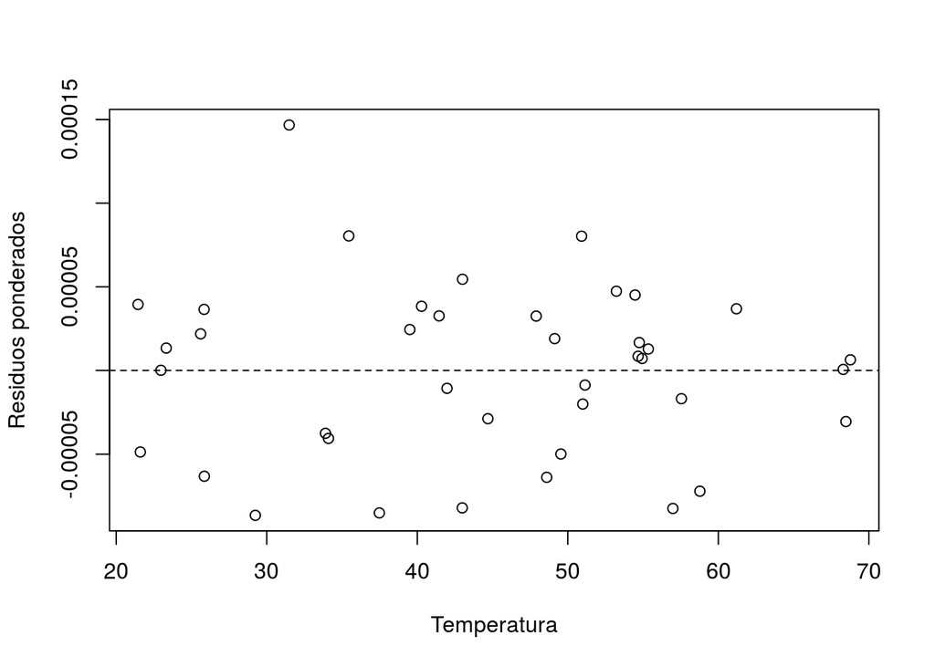

Gráfica de los residuos ponderados frente a la temperatura. Ya no se observa el aumento de varianza ligado al aumento de temperatura que se observaba en el modelo de regresión sin pesos.

```r
residuos <- sqrt(gas_pressure$temp^-g) * # square root of the weights
  gas_pressure_wlm$residuals # residuos

plot(gas_pressure$temp,
     residuos,
     ylab = "Residuos ponderados",
     xlab = "Temperatura")
abline(h=0, lty=2)
```

## 2g. Una solución alternativa es considerar un modelo GLS con la condición $\sigma_i = \gamma_0 + temp_i^{\gamma_1}$ y hallar los pesos que simultáneamente estiman los parámetros $\beta$ y las $\gamma$ por máxima verosimilitud. Para ello, disponemos del paquete `nlme` y su función `gls()`.

```r
# Fit model
gas_pressure_gls_mod <- gls(pressure ~ temp, data = gas_pressure, weights = varConstPower(form =~temp))
summary(gas_pressure_gls_mod)
```

```
## Generalized least squares fit by REML
##   Model: pressure ~ temp
##   Data: gas_pressure
##        AIC      BIC    logLik
##   234.2322 242.4202 -112.1161
##
## Variance function:
##  Structure: Constant plus power of variance covariate
##  Formula: ~temp
##  Parameter estimates:
##      const      power
## 0.09906465 2.36008616
##
## Coefficients:
##                Value Std.Error  t-value p-value
## (Intercept) 6.685184 1.1420721  5.85356       0
## temp        3.946379 0.0412054 95.77324       0
##
##  Correlation:
##      (Intr)
## temp -0.96
##
## Standardized residuals:
##        Min         Q1        Med         Q3        Max
## -1.9373696 -0.6547498  0.1737098  0.5516803  2.3900023
##
## Residual standard error: 0.0005607637
## Degrees of freedom: 40 total; 38 residual
```

**$\hat \gamma_0$:** 0.09906465  
**$\hat \gamma_1$:** 2.3600862  
**$\hat \beta_0$:** 6.685184  
**$\hat \beta_1$:** 3.9463787

## 2h. Dibujar el gráfico de dispersión que aparece al final del apartado 4.4.5.2 y añadir la recta del modelo GLS.

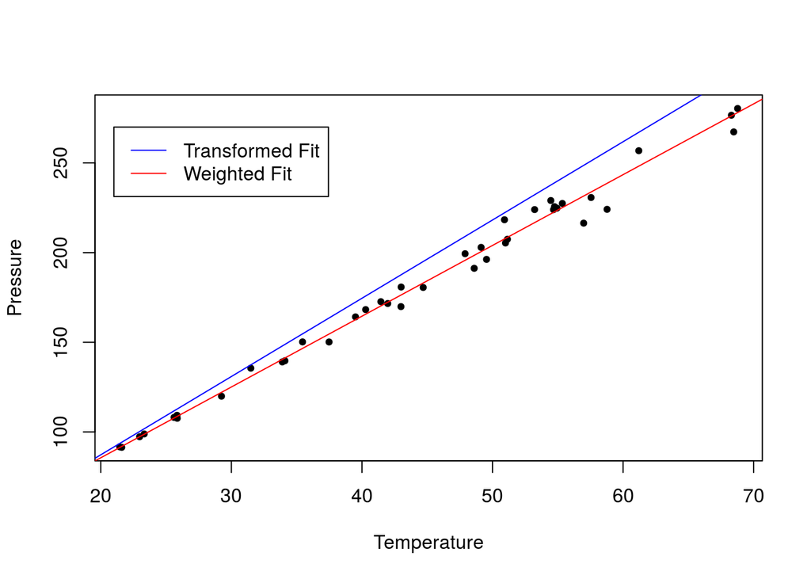

Gráfico de dispersión de presión frente a temperatura. La línea azul representa el ajuste al modelo de variables transformadas (inversa de presion frente a inversa de temperatura). La línea roja representa el ajuste al modelo ponderado por mínimos cuadrados generalizados. Este último parece ajustarse más a los datos.

```r
# Slope and intercept
transformed_fit <- c(coef(gas_mod_inv_p2))
weighted_fit <- c(gas_pressure_gls_mod$coefficients[[1]],
                  gas_pressure_gls_mod$coefficients[[2]])
# Scatterplot
plot(pressure ~ temp, data = gas_pressure,
     xlab = "Temperature",
     ylab = "Pressure",
     pch = 20)
# Fitted lines
abline(a = -transformed_fit[1]/transformed_fit[2],
       b= 1/transformed_fit[2], col = "blue")
abline(coef= weighted_fit, col = "red")
# Plot legend
legend(21, y = 270,
       legend = c("Transformed Fit", "Weighted Fit"),
       col = c("blue", "red"),
       lty = c(1,1))
```

# Apéndice A: Código

El documento original en formato .Rmd, que incluye el código completo en lenguaje R usado para generar este informe, se puede consultar y descargar en el siguiente repositorio de Github: jorgevallejo/Regresion_PEC2